# Donor Profile: Japan International Cooperation Agency (JICA)

## Focus Portfolio

Japan International Cooperation Agency’s portfolio showcases a concentrated funding scale of $3.2 million average per project, peaking at over $6.2 million. This financial commitment reflects substantial leverage potential in selected UNHCR regions, signaling a strategic priority for amplifying impact through targeted donor investments. The limited yet high-value scope presents a compelling case for scaling partnerships that maximize funds’ impact multiplier effect. Executive decision-makers must seize this opportunity to channel resources into proven high-return areas, align with JICA’s established donor framework, and mitigate risks by diversifying regional focus. Immediate investment can unlock new synergies, streamline emergency response capabilities, and foster innovation in resilience-building interventions. Elevate funding appeal by spotlighting these data-backed insights as critical levers driving measurable outcomes and strengthening UNHCR’s accountability to donors.

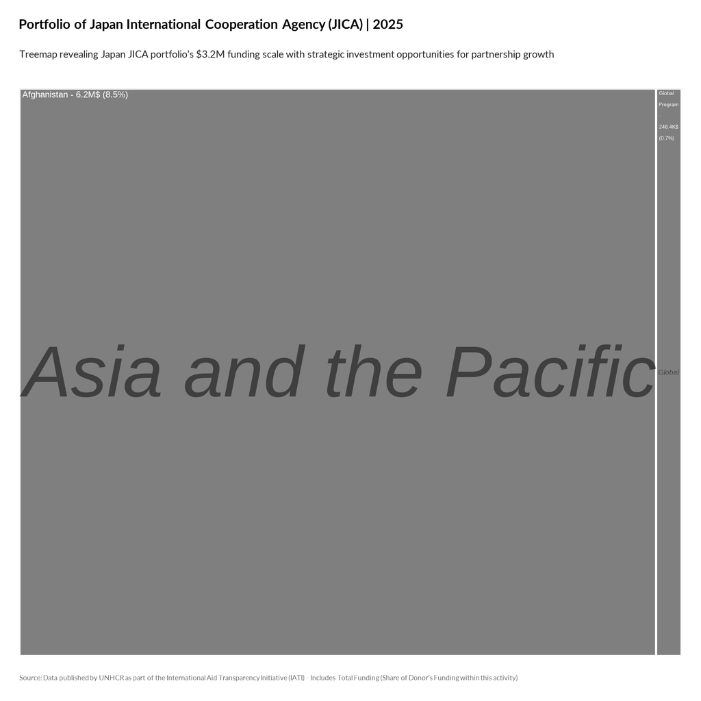

TRUE

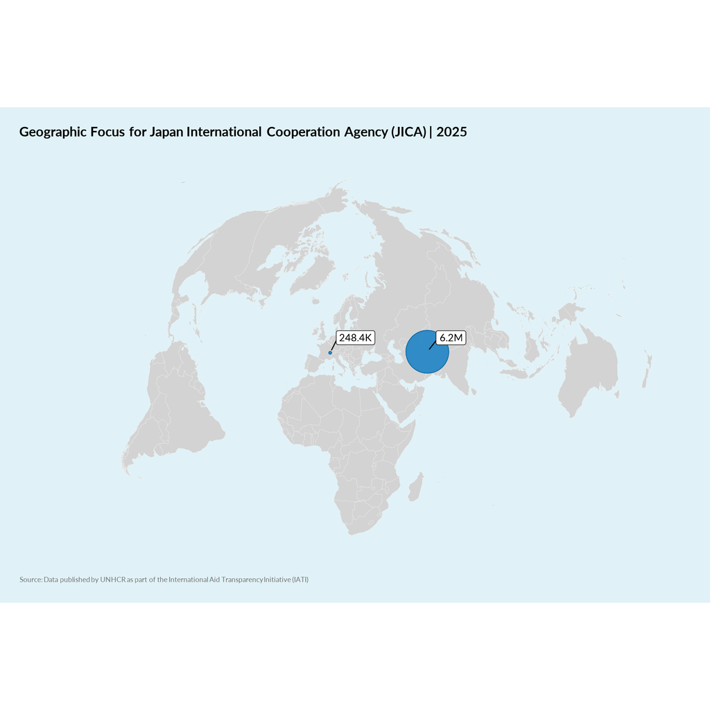

TRUE